# 2021年巴菲特致股东的信

2022年2月26日

沃伦·巴菲特

董事会主席

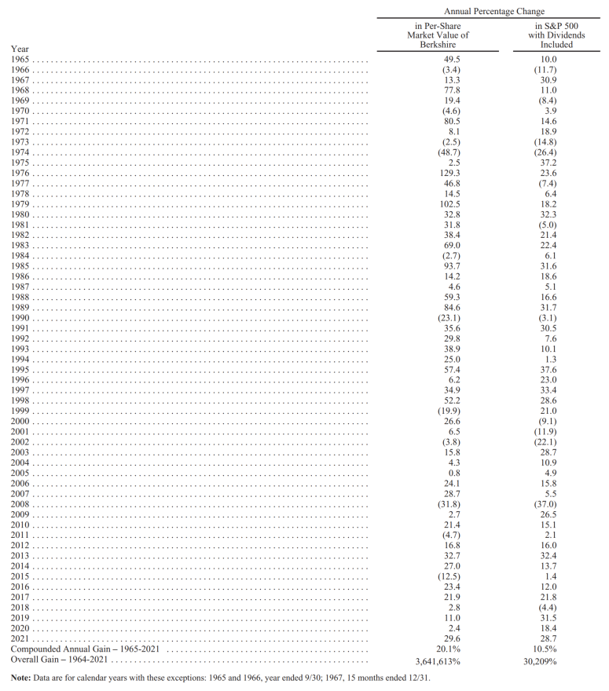

致伯克希尔哈撒韦公司股东：

查理·芒格是我的长期合作伙伴，我的工作是管理他的部分资产。能获得他的信任，我感到非常荣幸。

我们有责任向股东们报告大家想知道的情况。我们非常开心能够通过这封年度信件以及年度会议来与股东们直接沟通。

我们的政策是平等对待所有股东，因此我们不与分析师或大型机构进行讨论。我们会尽可能地在周六早上发布重要的信息，以便在周一开盘前，让股东和媒体有尽量多的时间来消化。

伯克希尔公司定期向SEC提交的年度10-K报告中列出了大量伯克希尔公司的事实和数据，这些也会在K-1至K-119页上呈现。

一些股东会觉得这些细节引人入胜，也有其他股东更愿意了解我和查理认为的在伯克希尔出现的那些新的或有趣的东西。

但在2021年，这些几乎没有。

不过，**我们确实在提高公司股票的内在价值方面取得了合理进展，这项任务是我57年来的首要职责，而且未来一直是。**

**1、股东们拥有什么**

伯克希尔拥有各种各样的公司，有些是全资控股，有些只是部分持股。

后者主要由美国大公司的可交易的普通股组成。

此外，我们还拥有一些海外资产，并参与了一些合资企业以及其他类型的合作项目。

无论我们的所有权形式如何，我们的目标都是对那些拥有护城河以及一流CEO的企业进行有意义的投资。

请特别注意，我们持有股票是基于我们对企业长期业务表现的预期，而不是拿来作为交易的工具。

这一点至关重要：查理和我不是在选股票，我们是在选商业模式和企业。

我也曾犯了很多错。所以最终结果是，我们广泛投资的企业中，包括一些具有真正非凡的企业，以及一些表现还不赖的企业，当然也有不怎么样的。

我们通过股票市场来投资，因为有时确实可以用便宜价格买到非常优秀的企业。这种“守株待兔”的做法在谈判交易中太罕见了，也不太会普遍存在。

但在二级市场，可以随时交易，错了也容易纠正。

**2、惊讶，惊讶**

以下是一些关于公司的信息，即使是经验丰富的投资者也常常感到惊讶：

**（1）许多人认为伯克希尔是一个庞大而有点奇怪的金融资产组合。事实上，伯克希尔拥有并运营的美国“基础设施”资产——在我们的资产负债表上被归类为不动产、厂房和设备——比其他任何美国公司都多。**

虽然这一优势从来不是我们追求的目标，但是这已经成为事实。

截至年底，伯克希尔的资产负债表上所记录的国内基础设施资产价值为1580亿美元。

这一数字在去年有所增加，未来还会继续，因为伯克希尔将持续前进。

**（2）伯克希尔每年都要缴纳大量的联邦所得税。**2021年我们就缴纳了33亿美元，而美国财政部报告的企业所得税收入总额为4020亿美元。此外，伯克希尔还缴纳了大量的州税和外国税。

可以说，伯克希尔的股东们“坐在办公室里都能为国做贡献”。

伯克希尔的历史生动说明了政府和美国企业之间那种无形又难以言说的纽带关系。

1955年初，伯克希尔精纺和哈撒韦制造同意合并他们的业务。在请求股东批准的过程中，这两家备受尊敬的新英格兰纺织公司对此次合并寄予厚望。

例如，哈撒韦的询价向股东保证“资源和管理的结合将造就纺织行业最强大、最高效的组织之一。”当时担任该公司顾问的雷曼兄弟也非常赞同这一乐观的说法。

我敢肯定，对于福尔河（伯克希尔）和新贝德福德（哈撒韦）来说，这是令人愉快的日子。然而，当乐队停止演奏、银行家们回家后，股东们将面临一场灾难。

在合并后的9年里，伯克希尔的所有者目睹了公司的净资产从5140万美元跌至2210万美元，部分是由于股票回购、欠考虑的股息政策以及工厂停产导致的。

但数千名员工9年的努力也带来了运营亏损。伯克希尔的困境并不罕见：新英格兰纺织业已经悄然进入了漫长且不可逆的死亡之旅。

在合并后的9年里，美国财政部也因伯克希尔而遇到了麻烦。在此期间内，公司只向政府缴纳了337,359美元的所得税——每天只有可怜的100美元。

1965年初，情况发生了变化。

伯克希尔有了新的管理层，重新分配了可用现金，并将所有收益基本都引导到了各种良好的业务中，其中大部分业务多年来一直保持良好。

收益的再投资与复利的力量结合在一起发挥了神奇的作用，股东们也因此赚钱了。

应该指出的是，伯克希尔的股东并不是这一航向调整中唯一受益者。背后“沉默的伙伴”——美国财政部持续从公司收取了数百亿美元的所得税。

还记得之前的每天100美元吗？现在，伯克希尔每天向财政部支付大约900万美元。

公平地说，对于我们的政府合作伙伴，我们的股东应该承认——事实上应该大肆宣扬——伯克希尔之所以有这样的繁荣，就是因为公司在美国。

如果没有伯克希尔，我们的国家在1965年以来的这些年里依旧可以取得辉煌的成就。然而，如果我们不是在美国，伯克希尔永远不会变成今天这个样子。

所以当你看到国旗时，请说声谢谢。

（3）**伯克希尔在1967年斥资860万美元收购了国家保险公司，现在已成为保险“浮存金”领域的世界领先者。**

“浮存金”是我们持有并可以用于投资的，不属于我们的资金。

包括一笔来自人寿保险的资金量相对较小的钱，伯克希尔的浮存金总额已经从刚进军保险领域时的1900万美元增长到了现在的1470亿美元。

到目前为止，这些浮动资金的成本几乎为零。虽然我们经历了保险损失加上运营费用超过保费的若干年份，但总体而言，我们获得了55年的适度利润。

同样重要的是，浮存金是非常具有粘性的。由于我们保险业务产生的资金每天都在变动，但总金额不会急剧下降，因此当用浮存金投资时，我们可以考虑长期投资。

如果你还不熟悉浮存金的概念，请参阅A-5页上的详细说明。

令人惊讶的是，去年我们的浮存金增加了90亿美元，这对伯克希尔公司的所有者来说非常重要，虽然没有反映在我们的GAAP（“公认会计原则”）的收益和净值报告中。

我们在保险业创造的巨大价值，很大程度上要归功于伯克希尔公司在1986年聘用了Ajit Jain（阿吉特·贾）。

我们第一次见面是在一个周六的上午，当时我就询问阿吉特在保险行业的经历，他的回答是“没有。”

我说“没有人是完美的”，然后雇佣了他。

那是我的幸运日：阿吉特实际上是一个非常完美的选择。更棒的是，35年后，他依然如此。

关于保险的最后想说的是：我认为伯克希尔的浮存金很可能——但远不能保证——不太会造成长期承保损失。

但我可以肯定的是，未来几年里会经历承保损失，而且涉及金额不小。

当然，伯克希尔在应对灾难性事件方面的能力是其他保险公司无法媲美的，而且这一优势在我和查理离开后还将持续保持下去。

**4、我们的四巨头**

通过伯克希尔，我们的股东拥有数十家企业，而其中一些公司也有自己的子公司。例如，Marmon有100多个独立业务，从铁路车辆租赁到医疗设备制造等等。

（1）尽管如此，我们“四大巨头”公司的运营占了伯克希尔公司价值的很大一部分。

领头的是我们的**保险业务**，伯克希尔拥有其100%的股份。我们之前也描述过该业务的巨大的浮存金价值，我们用这些浮存金不断投资以支持保险的最终保障承诺，结果投资规模越滚越大。

保险业务是为伯克希尔公司量身定做的，它永远不会过时，而且业务销量通常会随着经济增长和通货膨胀而不断增长。

此外，诚信和资本将一直非常重要，我们公司能够而且一定能表现得越来越好。

当然，也有其他一些保险公司拥有优秀的商业模式和前景。然而，复制伯克希尔的运营模式几乎是不可能的。

（2）苹果——以年终市值计算的亚军——是另外一种不同的持股方式。

我们对其的所有权仅为5.55%，高于一年前的5.39%，这个增幅感觉不值一提。

但考虑到苹果2021年的收益中，每0.1%的持股都是1亿美元。我们并没有花费伯克希尔的钱来进行增持，是苹果的回购起了作用。

重要的是，要知道伯克希尔的GAAP收益报告中只计算了苹果的股息。

去年，苹果支付了我们7.85亿美元的股息。然而，我们在苹果“持股份额”的利润达到了惊人的56亿美元。

公司保留的大部分资金用于回购苹果股份，我们对此表示赞赏。苹果杰出的首席执行官蒂姆·库克将苹果产品的用户视为自己的初恋，这很合理，但蒂姆的其他支持者也从他的管理风格中受益匪浅。

（3）BNSF（伯灵顿北方圣太菲铁路）是我们的第三大持仓，它依然是美国商业的头号动脉，是美国和伯克希尔不可或缺的资产。

如果BNSF运输的产品改用卡车运输，那么美国的碳排放量将会井喷。

2021年，BNSF的利润达到了创纪录的60亿美元。

这里需要指出的是，我们谈论的是我们喜欢的老式算法：扣除利息、税收、折旧、摊销和所有形式计提后的利润。（我们的这种算法也发出了一个警告：随着股市上涨，对收益的进行欺骗性的“调整”已经变得更加频繁，也更加不切实际。恕我直言，牛市让大家越来越膨胀了……）

BNSF的火车去年行驶了1.43亿英里，运送了5.35亿吨货物。

这两项成就都远远超过了其他任何一家美国铁路公司。大家可以为自己的铁路感到骄傲。

（4）我们的最后一只重仓股BHE（伯克希尔哈撒韦能源公司）在2021年赚了创纪录的40亿美元。

比2000年伯克希尔第一次购买BHE的股票时的利润（1.22亿美元增）增长了30多倍。现在，伯克希尔持有该公司91.1%的股份。

BHE的社会成就与其财务业绩一样引人注目。该公司在2000年没有风能，也没有太阳能发电。当时，它只是被认为是美国庞大的电力事业行业中一个相对较新的、较小的参与者。

随后，在大卫·索科尔和格雷格·阿贝尔的领导下，BHE成为了一家公用事业公司（请不要抱怨），以及美国风能、太阳能和输电领域的领军企业。

关于格雷格的这些成就的报告位于A-3和A-4页。你会发现那里的介绍绝对不是时下流行的“洗绿”（ 指企业伪装成环境之友,试图掩盖对社会和环境的破坏,以此保全和扩大自己的市场或影响力）故事。

自2007年开始，BHE每年都会详细介绍其在可再生能源和输电方面的计划和业绩。

想进一步了解这些信息，请访问BHE的网站brkenergy.com。在那里，你会看到该公司长期以来一直在实施应对气候变化的举措，这些举措耗尽了其所有的收入。但未来有更多的机会——BHE拥有良好的管理、经验、资本，可以满足国家对大型电力项目的需求。

现在让我们来谈谈我们没有控股的公司，这个表再次提到了苹果。

下表列出了我们持仓市值最大的15只股票，其中几只是伯克希尔的两位长期投资经理托德•库姆斯（Todd Combs）和特德•韦施勒（Ted Weschler）选择的。

到2021年底，这对明星投资经理对340亿美元的投资拥有完全的权力，其中许多投资都没有达到我们在表中使用的门槛值。

此外，托德和特德管理的相当大一部分资金存在伯克希尔旗下企业的各种养老金计划中，这些计划的资产未包含在此表中。

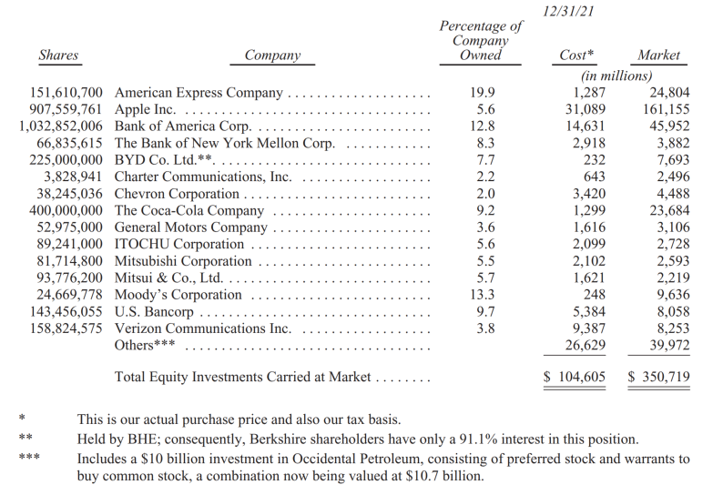

除了脚注位置的西方控股（Occidental holding）和各种普通股头寸外，伯克希尔哈撒韦公司还拥有卡夫亨氏（Kraft Hein）26.6% 的权益（采用“股权”方法计算，而非市场价值，价值为131亿美元）和Pilot 公司38.6%的权益。

Pilot公司是旅游中心的龙头企业，该公司去年的收入为 450 亿美元。

自从我们在 2017 年购买了Pilot的股份以来，这部分股份已进行了“股权”会计处理。

在2023年初，伯克希尔将购买Pilot的额外权益，这将使我们的所有权提高到80%，我们也会将Pilot的收益、资产和负债完全整合到我们的财务报表中。

**4、美国国债**

伯克希尔的资产负债表包括1440亿美元的现金和现金等价物（不包括持有的BNSF和BHE）。其中，1200亿美元以美国国债的形式持有，全部在一年之内到期。

1%的公开市场中的国债，有大约半数资金来自伯克希尔。

查理和我已承诺，伯克希尔将始终持有超过300亿美元的现金和等价物（包括除BNSF和BHE以外的子公司）。

我们希望伯克希尔在财务上坚不可摧，永不依赖陌生人（甚至朋友）的恩惠。

我们希望夜夜安枕，希望我们的债权人、保险投保人和股东们也如此。

但1440亿美元，会不会太多了？

我向你保证，这笔巨款并不是爱国主义的疯狂表现。查理和我也没有失去对“拥有一家企业”的压倒性偏好。

事实上，80年前的1942年3月11日，当我购买了三股Cities Services优先股时，我第一次表现出对拥有企业的热情。

它们的成本是114.75美元，花费了我所有的积蓄。（当天道琼斯工业平均指数收于99点，这一事实告诉我们：永远不要做空美国。）

在我最初遭受亏损之后，我总是将至少80%的净资产投资在股票上。在那段时间里，我最青睐的状态是满仓—现在仍然如此。

伯克希尔目前的仓位在80%左右，是因为我没找到符合我们长期持有标准的整个公司或其中一小部分（流通股）。

查理和我在过去不时忍受着类似的现金头寸很大的状况。这些时期从来都不令人愉快，也不是永久性的。

幸运的是，在2020年和2021年，我们找到一个温和的、有吸引力的替代现金的方案。

**5、股份回购**

我们可以通过三种方式增加股东的投资价值。

第一种方式始终是我们心仪的首选：通过内部增长或收购来提高伯克希尔控股企业的长期盈利能力。现在，内部增长带来的回报远高于收购。然而，与伯克希尔的资源相比，这些机会的规模很小。

我们的第二个选择是购买公开交易的优秀及伟大企业的流通股。有时，这样的可能性既多又极具吸引力。然而如今，我们几乎没有发现什么能让我们兴奋的东西。

这在很大程度上是因为一个真理：长期低利率推动所有生产性投资的价格上涨，无论是股票、地产、农业、原油等等。其他因素也会影响估值，但利率始终很重要。

我们创造价值的最后一条途径是回购伯克希尔的股票。

通过这个简单的举动，我们增加了股东在伯克希尔众多控股和非控股企业中的份额。

当价格跟价值相比很便宜时，这就是我们股东增加财富的最简单、最确定的方式。（除了为持续股东增加价值外，其他几方也获得了收益：回购对回购股份的卖方和社会都有一定的好处。）

随着其他途径越来越没有吸引力，回购对伯克希尔股东来说就很有意义了。

在过去两年中，我们回购了截止2019年末外部流通股的9%，总成本517亿美元。这笔支出使我们的长期股东拥有伯克希尔所有业务能够多出大约10%，无论这些业务是全资拥有（如BNSF和GEICO）还是部分拥有（如可口可乐和穆迪）。

我想强调的是，要使伯克希尔的股票回购有意义，我们的股票必须提供适当的价格。

我们既然不想为其他公司的股票多付钱，那如果我们在回购伯克希尔股票时支出过高，也得不偿失。

从去年年底到2022年2月23日以来，我们以12亿美元的成本回购了更多股票。我们的胃口仍然很大，但始终取决于价格。

必须得说，伯克希尔股票的回购机会有限，因为它拥有高品质的投资者。

如果我们的股票是被短期投机者大量持有，其价格波动和交易量都会大幅放大，这样可能给我们创造更多有价值的回购机会，让长期股东们从投机性回购中获利。

尽管如此，查理和我还是更喜欢我们现在的股东。

最后，伯克希尔所特有的容易被忽视的价值计算：正如我们已经讨论过的，正确的保险“浮存金”对我们来说是很有价值的。

事实上，回购会自动增加每股“浮存金”的金额。

这一数字在过去两年中增长了25%，从每股“A”类股79,387美元上升到99,497美元，这项收益意义很大。

正如前面提到的，这要归功于回购。

**6、一个了不起的人和一个了不起的事业**

去年，保罗·安德鲁斯去世了。

保罗是总部位于沃斯堡的伯克希尔子公司TTI的创始人兼首席执行官。

在他的一生中，无论是在事业上还是在个人追求上，保罗都不声不响地表现出了查理和我所钦佩的所有品质。他的故事应该被讲出来。

1971年，保罗在通用动力公司做采购代理。而在失去一份巨额的国防合同后，该公司解雇了包括保罗在内的数千名员工。

由于彼时他的第一个孩子即将出生，保罗决定赌上一把，用自己的500美元积蓄创建了德克萨斯电子公司(Tex-Tronic，后来改名为TTI)。

该公司成立的目标是销售小型电子元器件，第一年的销售额达到了总销售额11.2万美元。今天，TTI的产品市场超过100万种，年销售额达77亿美元。

但回到2006年：63岁的保罗发现自己与家人、工作和同事相处得很幸福。但他有一个挥之不去的担忧，因为他最近亲眼目睹了一个朋友的早逝，以及随之而来的对其家庭和生意造成的灾难性后果，这让他的担忧更加严重。

保罗在2006年问自己，如果他意外死亡，许多依靠他的人将会发生什么?

整整一年，保罗都在为自己的选择而苦苦挣扎。把公司卖给竞争对手？从严格的经济学观点来看，这条路线最有意义。毕竟，竞争对手可以预见到利润丰厚的“协同效应”——当收购者削减TTI的重复职能时，可以实现成本节省。

但是……这样的买家肯定还会保留其首席财务官、法律顾问和人力资源部门。

因此，TTI公司的同一职能部门将被集体裁员。而且，如果需要一个新的配送中心，收购方的家乡城市肯定会比沃斯堡更受青睐。

不管财务效益如何，保罗很快就得出结论，把公司卖给竞争对手不适合他。接下来，他考虑寻找一个金融买家——这个物种曾被恰当地称为杠杆收购公司。然而保罗知道，这样的买家会专注于“退出策略”。

谁知道那会是什么呢？ 考虑到这一切，保罗发现自己没有兴趣将他35年以来苦心经营的成果交给一个中间商。

当保罗见到我时，他解释了为什么他把这两个备选买家排除在外。然后他用比这更委婉的措辞总结了他的困境——“在考虑了一年其他选择后，我想把公司卖给伯克希尔，因为你是唯一剩下的人。”

所以我提出了报价，保罗答应了。一次会面，一顿午餐，达成了一笔交易。

用“从此过上了幸福的生活”来形容我俩都显得平淡无奇。

当伯克希尔收购TTI时，该公司雇佣了2387名员工。现在这个数字是8043。其中很大一部分增长发生在沃斯堡及其周边地区。公司的盈利增长了673%。

每年，我都会打电话给保罗，告诉他，他的薪水应该大幅增加。而每年，他都会告诉我，“我们可以明年再谈，沃伦，我现在太忙了。”

当我和格雷格•阿贝尔参加保罗的追悼会时，我们见到了他的子孙辈、长期合作伙伴（包括TTI的第一位员工），和约翰•罗奇（John Roach），他是伯克希尔于2000年收购的沃斯堡一家公司的前首席执行官。正是约翰把保罗引到奥马哈的，他本能地知道我们会是绝配。

在追悼会上，我和格雷格听说了保罗默默支持的许多人和组织。他的慷慨非同寻常——始终致力于改善他人的生活，尤其是沃斯堡的人们。

在所有方面，保罗都是个杰出的人。

运气——偶尔是非凡的运气——在伯克希尔发挥了作用。如果保罗和我没有共同的朋友——约翰•罗奇，TTI也不会在我们这里安家。但这充足的运气仅仅是个开始。TTI很快就将伯克希尔引向了其最重要的收购。

每年秋天，伯克希尔的董事们都会聚集在一起，听我们的几位高管讲话。

我们有时会根据近期收购的地点来选择会议地点，这意味着董事们可以与新子公司的首席执行官会面，并了解更多关于被收购方的活动。

在2009年秋天，我们因此选择了沃斯堡，以便我们可以访问TTI。当时，总部同样位于沃思堡的BNSF是我们持有股份第三多的公司。尽管有这么多的股份，我却从来没有去过这家铁路公司的总部。

我的助理黛布·博萨内克（Deb Bosanek）将董事会的开幕晚宴安排在10月22日。与此同时，那天我安排早些时候会见马特·罗斯（Matt Rose），他是BNSF的首席执行官。

我一直钦佩他的成就。当我确定这个日期的时候，我没有想到我们的聚会将与BNSF在22日晚些时候发布第三季度盈利报告同时举行。

市场对这家铁路公司的业绩反应不佳。“大衰退”在那年第三季度全面爆发，BNSF的收益情况反映了这种衰退。经济前景也很黯淡，华尔街对铁路也不友好。

第二天，我再次与马特会面，并建议伯克希尔将为铁路公司提供一个比作为上市公司所能期望的更好的长期归宿。我还告诉他伯克希尔愿意支付的最高价格。

马特将这一提议转达给了他的董事和顾问。经过忙碌的11天后，伯克希尔和BNSF宣布了一项确定交易。

在这里，我冒险做出一个罕见的预测：BNSF未来一个世纪，成为伯克希尔乃至美国最核心的资产。

如果保罗•安德鲁斯没有将伯克希尔视为TTI的合适归宿地，BNSF的收购就永远不会发生。

**7、致谢**

70年前，我教授了我的第一堂投资课。从那时起，我几乎每年都很享受与各个年龄段的学生一起工作，最终我在2018年从这个追求中 "退休"。

一路走来，我最艰难的听众是我孙子的五年级班级。这些11岁的孩子在座位上扭来扭去，茫然地看着我，直到我提到可口可乐(Coca-Cola)及其著名的秘密配方时。瞬间，每个人都举起手来，我明白了“秘密”对孩子们来说是一种诱惑。

教学就像写作一样，帮助我发展和理清了自己的思路。查理把这种现象称为猩猩效应：如果你和一只猩猩坐在一起，向它仔细解释你所珍视的一个想法，你可能会留下一只迷惑不解的灵长类动物，但你自己的思维会更清晰。

和大学生交谈则要有效得多。我敦促他们在：

（1）专业领域找工作；

（2）如果他们不差钱的话，找他们想选择的人一起工作。

我承认，经济现实可能会干扰这种选择。

即便如此，我还是敦促学生们永远不要放弃追求，因为当他们找到那种热爱的工作时，他们就不再是“社畜”了。

查理和我在经历了一些早期的挫折后，走上了这条自由的道路。我们都曾在我祖父的杂货店里做兼职——查理1940年、我1942年。我们都被分配了无聊的任务，报酬也少，这绝对不是我们想要的。

后来，查理开始从事法律工作，而我则尝试着卖证券。我们对工作的满意度仍然不高。

最后，在伯克希尔，我们找到了自己喜欢做的事情。除了极少数例外，我们现在已经与我们喜欢和信任的人“工作”了几十年。

与保罗•安德鲁斯（Paul Andrews）或我去年说过的伯克希尔大家庭这样的经理人共事，是一种生活乐趣。

在我们的总部，我们雇佣正派和有才华的人，没有一个人是笨蛋。每年的平均流动率大概是一个人。

不过我想强调另一件事，它使我们的工作变得有趣和令人满意——为股东工作。对查理和我来说，没有什么比获得个人长期股东的信任更值得的了。

几十年来，他们加入我们，期望我们成为他们资金的可靠托管人。

显然，我们不能选择我们的股东，如果我们的经营形式是合伙的话，我们可以这样做。任何人现在都可以购买伯克希尔的股票，并打算很快再出售这些股票。

当然，我们会有一些这样的股东，就像我们会有指数基金持有大量伯克希尔股票，只是因为它们被要求这么做。

伯克希尔拥有一个庞大的个人和家庭团队，他们选择加入我们的行列，且“至死不渝”，这非常不同寻常。通常他们把储蓄的很大一部分——对有些人来说可能是过多的存款——托付给我们。

这些股东有时会觉得，伯克希尔可能远不是他们能做出的最佳选择。但他们会补充说，伯克希尔在他们最满意的公司中已经排名非常靠前。

平均而言，那些对自己的投资感到满意的人，会比那些被不断变化的新闻、传言和承诺所影响的人会取得更好的结果。

长期个人股东既是我和查理一直寻求的“合作伙伴”，也是我们在伯克希尔做出决策时一直考虑的目标群体。

我们想对他们说：“为你们‘工作’感觉很好，非常感谢你们的信任。”

**8、年度股东大会**

日期已经确定！伯克希尔将于4月29日星期五至5月1日星期日在奥马哈举行年度股东大会。详细情况见A-1和A-2页。奥马哈和我都热切期待你们的到来。

在这封信的结尾，我顺便打个广告。“表弟”吉米·巴菲特设计了一艘浮筒式“派对”游艇，目前由伯克希尔的子公司Forest River制造。这艘船将于4月29日在伯克希尔股东大会上发布。限时两天内，股东们可以以10%的折扣购买吉米的杰作。你们的董事长会买一艘给家人使用，快加入我们吧。